# Bad weather Kelheim Demo

Oleksandr Soboliev

## **Research Meteostat**

After some researches about meteostat data nearest station in DE that belongs to Kelheim region are:

- “Mallersdorf-Pfaffenberg/Niederbayern” with an id: “D3147”
- “Neumarkt / Höhenberg” with and id: “69110”
- Uebungsdorf / Emhof

there are many of them so I am starting to think about extracting all from the Bayern or extract the nearest from longtitude/latitude point with the Kelheim shapefile(using json and Euclid distances)

[Kelheim has no weather station, but it could be reconstructed with 2 other](https://weatherspark.com/y/70370/Average-Weather-in-Kelheim-Germany-Year-Round)

Hohenfels with id: “10775” and Ingolstadt with id:“10860” **kelheim_data = {weight1}x{hohenfels} + {weight2}x{inglstadt}**

Also this site shows, that there are many of the Kelheim stations in this area, but meteostat doesn’t contain them https://www.wunderground.com/dashboard/pws/IKELHE5

## **Research Weatherstack**

```r
weatherstack_kelheim = read_delim("data/Kelheim_weather_since_july_2008.csv",delim = ",")
print(weatherstack_kelheim)
```

| date | hour | description | precip | visibility | totalsnow_daily |
| --- | --- | --- | --- | --- | --- |
| 2008-07-01 | 0 | Clear | 0.0 | 10 | 0 |
| 2008-07-01 | 100 | Clear | 0.0 | 10 | 0 |
| 2008-07-01 | 200 | Clear | 0.0 | 10 | 0 |
| 2008-07-01 | 300 | Clear | 0.0 | 10 | 0 |
| 2008-07-01 | 400 | Clear | 0.0 | 10 | 0 |
| 2008-07-01 | 500 | Clear | 0.0 | 10 | 0 |
| 2008-07-01 | 600 | Sunny | 0.0 | 10 | 0 |
| 2008-07-01 | 700 | Sunny | 0.0 | 10 | 0 |
| 2008-07-01 | 800 | Sunny | 0.0 | 10 | 0 |
| 2008-07-01 | 900 | Sunny | 0.0 | 10 | 0 |

[output cut: 990 more lines]

What to take as a reffer point isn’t clear because of the date(before/after covid) and weather type (sunny,clear,temperature) Also there is no temperature in it :/

## **Import mobility from Google**

```r
#global_mobility = read_delim("https://www.gstatic.com/covid19/mobility/Global_Mobility_Report.csv",",")
#de_mobility = global_mobility %>% filter(country_region_code == "DE")
```

```r
#print(unique(de_mobility$sub_region_1))
```

As we can see the most precise region to filter data from is Bavaria :/

```r
#bavaria_mobility = de_mobility %>% filter(sub_region_1 == "Bavaria")
#bavaria_mobility = bavaria_mobility %>% #dplyr::select(country_region,sub_region_1,date,residential_percent_change_from_baseline) %>%
#  mutate(residential_percent_change_from_baseline = -residential_percent_change_from_baseline,
#         source = "Google")%>%
#  rename(BundeslandID = sub_region_1,not_at_home_change = residential_percent_change_from_baseline)
#bavaria_mobility = bavaria_mobility %>% dplyr::select(date,BundeslandID,not_at_home_change,source)
#Need to filter out weekends

#plt = ggplot(bavaria_mobility)+
#  geom_point(aes(x = date,y = not_at_home_change))
#ggplotly(plt)
```

## **Import mobility from Senozon**

```r
snz_mobility = read_delim("data/LK_mobilityData_weekdays.csv",";")
#Kelheim
snz_mobility_kelheim = snz_mobility %>% filter(Landkreis == "Landkreis Kelheim") %>% mutate(source = "senozon") %>% dplyr::select(-outOfHomeDuration) %>% rename(not_at_home_change = percentageChangeComparedToBeforeCorona)
snz_mobility_kelheim$date = as.Date(strptime(snz_mobility_kelheim$date,"%Y%m%d"))

#Berlin
snz_mobility_berlin = snz_mobility %>% filter(Landkreis == "Berlin") %>% mutate(source = "senozon") %>% dplyr::select(-outOfHomeDuration) %>% rename(not_at_home_change = percentageChangeComparedToBeforeCorona)
snz_mobility_berlin$date = as.Date(strptime(snz_mobility_berlin$date,"%Y%m%d"))

colors <- c("Berlin" = "blue", "Kelheim" = "red")

plt = ggplot()+
  geom_point(data = snz_mobility_kelheim,aes(x = date,y = not_at_home_change,color = "Berlin"))+
  geom_point(data = snz_mobility_berlin,aes(x = date,y = not_at_home_change,color = "Kelheim"))+
  scale_colour_manual(values = colors)
ggplotly(plt)
```

[interactive chart not shown]

## **Aggregate 2 sources**

We take berlin weather from station in Schoenefeld with id = 10384

```r
# think about duration of description column
# Kelheim
weatherstack_kelheim_daily = weatherstack_kelheim %>%
  group_by(date) %>%
  summarize(description = description,precip_day = sum(precip),visibility_mean = mean(visibility),totalsnow_daily = mean(totalsnow_daily))
weatherstack_kelheim_weekly = weatherstack_kelheim_daily %>%
  mutate(year_week = paste0(isoyear(date),"-",isoweek(date))) %>%
  group_by(year_week) %>%
  summarize(description = description,date = first(date), precip_week = sum(precip_day),visibility_mean = mean(visibility_mean),totalsnow_weekly =sum( totalsnow_daily))
weatherstack_kelheim_weekly = unique(weatherstack_kelheim_weekly)
print(weatherstack_kelheim_weekly)
```

| year_week | description | date | precip_week | visibility_mean | totalsnow_weekly |
| --- | --- | --- | --- | --- | --- |
| 2008-27 | Clear | 2008-07-01 | 184.8 | 9.222222 | 0.0 |
| 2008-27 | Sunny | 2008-07-01 | 184.8 | 9.222222 | 0.0 |
| 2008-27 | Partly cloudy | 2008-07-01 | 184.8 | 9.222222 | 0.0 |
| 2008-27 | Patchy light rain | 2008-07-01 | 184.8 | 9.222222 | 0.0 |
| 2008-27 | Moderate rain | 2008-07-01 | 184.8 | 9.222222 | 0.0 |
| 2008-27 | Light drizzle | 2008-07-01 | 184.8 | 9.222222 | 0.0 |
| 2008-27 | Patchy light drizzle | 2008-07-01 | 184.8 | 9.222222 | 0.0 |
| 2008-27 | Mist | 2008-07-01 | 184.8 | 9.222222 | 0.0 |
| 2008-27 | Fog | 2008-07-01 | 184.8 | 9.222222 | 0.0 |
| 2008-28 | Fog | 2008-07-07 | 1288.8 | 8.202381 | 0.0 |

[output cut: 990 more lines]

```r
#Berlin

berlin_weather_weekly = berlin_weather_daily %>% filter(year(date) >=2020) %>%
  mutate(year_week = paste0(isoyear(date),"-",isoweek(date))) %>%
  group_by(year_week) %>%
  summarize(date = first(date), prcp_week = sum(prcp), tavg= mean(tavg),snow_week =sum( snow),wspd = mean(wspd),tmax = max(tmax)) %>%
  arrange(year_week)
print(berlin_weather_weekly)
```

| year_week | date | prcp_week | tavg | snow_week | wspd | tmax |
| --- | --- | --- | --- | --- | --- | --- |
| 2020-1 | 2020-01-01 | 10.5 | 2.2400000 | 0 | 17.480000 | 7.2 |
| 2020-10 | 2020-03-02 | 7.6 | 4.7000000 | 0 | 15.314286 | 10.3 |
| 2020-11 | 2020-03-09 | 16.0 | 6.6000000 | 0 | 22.457143 | 13.8 |
| 2020-12 | 2020-03-16 | 0.0 | 7.1714286 | 0 | 14.028571 | 17.3 |
| 2020-13 | 2020-03-23 | 0.1 | 4.5428571 | 0 | 15.828571 | 15.9 |
| 2020-14 | 2020-03-30 | 0.1 | 5.0142857 | 0 | 15.842857 | 16.2 |
| 2020-15 | 2020-04-06 | 3.7 | 12.0000000 | 0 | 11.014286 | 23.7 |
| 2020-16 | 2020-04-13 | 0.1 | 9.3000000 | 0 | 17.028571 | 18.1 |
| 2020-17 | 2020-04-20 | 0.0 | 12.0285714 | 0 | 15.057143 | 22.5 |
| 2020-18 | 2020-04-27 | 27.3 | 12.7714286 | 0 | 13.214286 | 24.0 |

[output cut: 138 more lines]

```r
NA
```

```r
#mob_joined = rbind(snz_mobility_kelheim,bavaria_mobility)
#Kelheim
snz_mobility_kelheim_year_week = snz_mobility_kelheim %>%
  mutate(year_week = paste0(isoyear(date),"-",isoweek(date))) %>%
  group_by(year_week) %>%
  summarize(date = first(date),not_at_home_change = mean(not_at_home_change))
mob_joined_with_weather_kelheim = snz_mobility_kelheim_year_week %>% inner_join(weatherstack_kelheim_weekly, by = "year_week") %>% dplyr::select(-date.y) %>% rename(date = date.x)
print(mob_joined_with_weather_kelheim)
```

| year_week | date | not_at_home_change | description | precip_week | visibility_mean | totalsnow_weekly |
| --- | --- | --- | --- | --- | --- | --- |
| 2020-10 | 2020-03-06 | 0 | Partly cloudy | 652.8 | 8.630952 | 33.6 |
| 2020-10 | 2020-03-06 | 0 | Light rain | 652.8 | 8.630952 | 33.6 |
| 2020-10 | 2020-03-06 | 0 | Light sleet showers | 652.8 | 8.630952 | 33.6 |
| 2020-10 | 2020-03-06 | 0 | Patchy rain possible | 652.8 | 8.630952 | 33.6 |
| 2020-10 | 2020-03-06 | 0 | Overcast | 652.8 | 8.630952 | 33.6 |
| 2020-10 | 2020-03-06 | 0 | Moderate or heavy sleet | 652.8 | 8.630952 | 33.6 |
| 2020-10 | 2020-03-06 | 0 | Patchy heavy snow | 652.8 | 8.630952 | 33.6 |
| 2020-10 | 2020-03-06 | 0 | Light sleet | 652.8 | 8.630952 | 33.6 |
| 2020-10 | 2020-03-06 | 0 | Moderate rain | 652.8 | 8.630952 | 33.6 |
| 2020-10 | 2020-03-06 | 0 | Mist | 652.8 | 8.630952 | 33.6 |

[output cut: 990 more lines]

```r
#Berlin
snz_mobility_berlin_year_week = snz_mobility_berlin %>%
  mutate(year_week = paste0(isoyear(date),"-",isoweek(date))) %>%
  group_by(year_week) %>%
  summarize(date = first(date),not_at_home_change = mean(not_at_home_change))
mob_joined_with_weather_berlin = snz_mobility_berlin_year_week %>% inner_join(berlin_weather_weekly, by = "year_week") %>% dplyr::select(-date.y) %>% rename(date = date.x)
print(mob_joined_with_weather_berlin)
```

| year_week | date | not_at_home_change | prcp_week | tavg | snow_week | wspd | tmax |
| --- | --- | --- | --- | --- | --- | --- | --- |
| 2020-10 | 2020-03-06 | 0 | 7.6 | 4.7000000 | 0 | 15.314286 | 10.3 |
| 2020-11 | 2020-03-13 | -4 | 16.0 | 6.6000000 | 0 | 22.457143 | 13.8 |
| 2020-12 | 2020-03-20 | -26 | 0.0 | 7.1714286 | 0 | 14.028571 | 17.3 |
| 2020-13 | 2020-03-27 | -39 | 0.1 | 4.5428571 | 0 | 15.828571 | 15.9 |
| 2020-14 | 2020-04-03 | -37 | 0.1 | 5.0142857 | 0 | 15.842857 | 16.2 |
| 2020-15 | 2020-04-10 | 0 | 3.7 | 12.0000000 | 0 | 11.014286 | 23.7 |
| 2020-16 | 2020-04-17 | -32 | 0.1 | 9.3000000 | 0 | 17.028571 | 18.1 |
| 2020-17 | 2020-04-24 | -27 | 0.0 | 12.0285714 | 0 | 15.057143 | 22.5 |
| 2020-18 | 2020-05-01 | 9 | 27.3 | 12.7714286 | 0 | 13.214286 | 24.0 |
| 2020-19 | 2020-05-08 | 22 | 1.8 | 12.3142857 | 0 | 12.300000 | 23.7 |

[output cut: 122 more lines]

```r
#First plot with colour as precipitation
shapes <- c("Berlin" = 5, "Kelheim" = 3)
plt_color = ggplot()+
  geom_point(data = mob_joined_with_weather_kelheim,aes(x = date,y = not_at_home_change,colour = precip_week,shape = "Kelheim"))+
  #geom_point(data = mob_joined_with_weather_berlin,aes(x = date,y = not_at_home_change,colour = prcp_week,shape = "Berlin"))+
  scale_color_gradient2()+
  scale_shape_manual(values = shapes)


ggplotly(plt_color)
```

[interactive chart not shown]

```r
#Second plot as another line as precipitation
plt_line = ggplot(mob_joined_with_weather_kelheim)+
  geom_point(aes(x = date,y = not_at_home_change))+
  geom_line(aes(x = date,y = precip_week*0.5,color = "red"))


ggplotly(plt_line)
```

[interactive chart not shown]

```r
plt_hist_precip = ggplot(mob_joined_with_weather_kelheim,aes(x = precip_week,y = not_at_home_change))+
  stat_summary_bin(fun = "mean",
                   geom = "bar",
                   binwidth = 2,fill = "blue")

ggplotly(plt_hist_precip)
```

[interactive chart not shown]

```r
plt_hist_visibility = ggplot(mob_joined_with_weather_kelheim,aes(x = visibility_mean,y = not_at_home_change))+
  stat_summary_bin(fun = "mean",
                   geom = "bar",
                   binwidth = 0.5,fill = "blue")

ggplotly(plt_hist_visibility)
```

[interactive chart not shown]

```r
plt_hist_totalsnow = ggplot(mob_joined_with_weather_kelheim,aes(x = totalsnow_weekly,y = not_at_home_change))+
  stat_summary_bin(fun = "mean",
                   geom = "bar",
                   binwidth = 7,fill = "blue")

ggplotly(plt_hist_totalsnow)
```

[interactive chart not shown]

```r
#this is a bad plot because it takes description of 1 day of the week
plt_hist_descr = ggplot(mob_joined_with_weather_kelheim,aes(x = description,y = not_at_home_change))+
  stat_summary_bin(fun = "mean",
                   geom = "bar",
                   binwidth = 5,fill = "blue")+
  coord_flip()

ggplotly(plt_hist_descr)
```

[interactive chart not shown]

## Let’s try it out with meteostat data, that contains scope of the 2022 without restictions

Ingolstadt data from id = 10860 station

```r
ingolstadt_weather = read_delim("https://bulk.meteostat.net/v2/daily/10860.csv.gz",",",col_names = FALSE)
colnames(ingolstadt_weather) = c("date", "tavg", "tmin", "tmax", "prcp", "snow", "wdir", "wspd", "wpgt", "pres", "tsun")


# We don't need data of weather before 2020, because of snz_mobility date, also data isn't precise

ingolstadt_weather = ingolstadt_weather %>% filter(year(date)>=2020)%>% replace_na(list(snow = 0))

print(ingolstadt_weather)
```

| date | tavg | tmin | tmax | prcp | snow | wdir | wspd | wpgt | pres | tsun |
| --- | --- | --- | --- | --- | --- | --- | --- | --- | --- | --- |
| 2020-01-01 | -0.8 | -3.5 | 3.4 | 0.0 | 0 | 70 | 6.5 | 20.5 | 1036.1 | NA |
| 2020-01-02 | -2.9 | -6.1 | -1.2 | 0.0 | 0 | 243 | 4.0 | 16.6 | 1032.7 | NA |
| 2020-01-03 | 1.2 | -2.4 | 5.9 | 0.3 | 0 | 218 | 7.2 | 29.5 | 1028.0 | NA |
| 2020-01-04 | 4.4 | 3.4 | 6.2 | 0.5 | 0 | 278 | 20.5 | 48.2 | 1030.0 | NA |
| 2020-01-05 | 2.8 | -1.8 | 4.5 | 0.0 | 0 | 271 | 9.0 | 38.9 | 1036.6 | NA |
| 2020-01-06 | -1.2 | -3.7 | 4.5 | 0.0 | 0 | 119 | 4.3 | 14.8 | 1032.1 | NA |
| 2020-01-07 | -0.4 | -5.0 | 2.6 | 0.9 | 0 | 233 | 5.0 | 24.1 | 1031.5 | NA |
| 2020-01-08 | 1.0 | -2.3 | 3.2 | 0.0 | 0 | 100 | 2.9 | 13.0 | 1031.7 | NA |
| 2020-01-09 | 4.3 | -0.1 | 10.8 | 0.0 | 0 | 109 | 2.9 | 11.2 | 1023.6 | NA |
| 2020-01-10 | 4.9 | -1.2 | 11.2 | 0.2 | 0 | 230 | 9.4 | 37.1 | 1023.0 | NA |

[output cut: 990 more lines]

Hohenfels data from id = 10775 station

```r
hohenfels_weather = read_delim("https://bulk.meteostat.net/v2/daily/10775.csv.gz",",",col_names = FALSE)
colnames(hohenfels_weather) = c("date", "tavg", "tmin", "tmax", "prcp", "snow", "wdir", "wspd", "wpgt", "pres", "tsun")


# We don't need data of weather before 2020, because of snz_mobility date, also data isn't precise

hohenfels_weather = hohenfels_weather %>% filter(year(date)>=2020) %>% replace_na(list(snow = 0))

print(hohenfels_weather)
```

| date | tavg | tmin | tmax | prcp | snow | wdir | wspd | wpgt | pres | tsun |
| --- | --- | --- | --- | --- | --- | --- | --- | --- | --- | --- |
| 2020-01-01 | -4.3 | -8.2 | 1.5 | NA | 0 | NA | NA | NA | NA | NA |
| 2020-01-02 | -4.5 | -9.7 | -0.7 | NA | 0 | 355 | 0.6 | NA | 1033.0 | NA |
| 2020-01-03 | 0.5 | -2.5 | 4.5 | NA | 0 | 153 | 3.7 | NA | 1027.5 | NA |
| 2020-01-04 | 3.4 | 2.2 | 5.7 | NA | 0 | 264 | 15.5 | NA | 1028.5 | NA |
| 2020-01-05 | 1.3 | -2.1 | 3.3 | NA | 0 | 334 | 3.7 | NA | 1036.2 | NA |
| 2020-01-06 | -1.1 | -3.6 | 2.5 | NA | 0 | 18 | 2.1 | NA | 1032.2 | NA |
| 2020-01-07 | 0.2 | -3.4 | 3.0 | NA | 0 | 332 | 2.6 | NA | 1030.6 | NA |
| 2020-01-08 | 1.5 | 0.2 | 2.6 | NA | 0 | 84 | 3.4 | NA | NA | NA |
| 2020-01-09 | 4.1 | 1.5 | 9.3 | NA | 0 | 35 | 2.3 | NA | 1023.9 | NA |
| 2020-01-10 | 5.1 | 1.3 | 9.4 | NA | 0 | 323 | 3.8 | NA | 1021.8 | NA |

[output cut: 981 more lines]

As we can see in Hohenfels data isn’t that accurate and precipitation is data is missing fr year 2020, so for the further analysis we take only Ingolstadt data.

```r
ingolstadt_weather_weekly = ingolstadt_weather %>%
  mutate(year_week = paste0(isoyear(date),"-",isoweek(date))) %>%
  group_by(year_week) %>%
  summarize(date = first(date), prcp_week = sum(prcp), tavg= mean(tavg),snow_week =sum( snow),wspd = mean(wspd),tmax = max(tmax)) %>%
  arrange(year_week)
#ingolstadt_weather_weekly = unique(weatherstack_kelheim_weekly)
print(ingolstadt_weather_weekly)
```

| year_week | date | prcp_week | tavg | snow_week | wspd | tmax |
| --- | --- | --- | --- | --- | --- | --- |
| 2020-1 | 2020-01-01 | 0.8 | 0.9400000 | 0 | 9.440000 | 6.2 |
| 2020-10 | 2020-03-02 | 13.9 | 4.1428571 | 0 | 13.157143 | 9.6 |
| 2020-11 | 2020-03-09 | 13.1 | 7.1428571 | 0 | 15.428571 | 17.7 |
| 2020-12 | 2020-03-16 | 9.9 | 7.1571429 | 0 | 9.214286 | 19.0 |
| 2020-13 | 2020-03-23 | 0.0 | 4.4428571 | 0 | 14.185714 | NA |
| 2020-14 | 2020-03-30 | 0.0 | 4.6142857 | 0 | 7.857143 | 17.3 |
| 2020-15 | 2020-04-06 | 0.0 | 12.1857143 | 0 | 5.228571 | 22.4 |
| 2020-16 | 2020-04-13 | 3.8 | 10.9285714 | 0 | 8.228571 | 23.6 |
| 2020-17 | 2020-04-20 | 0.0 | 12.9000000 | 0 | 14.742857 | 21.0 |
| 2020-18 | 2020-04-27 | 18.6 | 11.3428571 | 0 | 10.342857 | 20.1 |

[output cut: 138 more lines]

```r
mob_joined_with_ingolstadt = ingolstadt_weather_weekly %>%
  inner_join(snz_mobility_kelheim_year_week, by = "year_week") %>%
  dplyr::select(-date.x) %>%
  rename(date = date.y) %>%
  replace_na(list(tmax = 0))

print(mob_joined_with_ingolstadt)
```

| year_week | prcp_week | tavg | snow_week | wspd | tmax | date | not_at_home_change |
| --- | --- | --- | --- | --- | --- | --- | --- |
| 2020-10 | 13.9 | 4.1428571 | 0 | 13.157143 | 9.6 | 2020-03-06 | 0 |
| 2020-11 | 13.1 | 7.1428571 | 0 | 15.428571 | 17.7 | 2020-03-13 | 0 |
| 2020-12 | 9.9 | 7.1571429 | 0 | 9.214286 | 19.0 | 2020-03-20 | -14 |
| 2020-13 | 0.0 | 4.4428571 | 0 | 14.185714 | 0.0 | 2020-03-27 | -23 |
| 2020-14 | 0.0 | 4.6142857 | 0 | 7.857143 | 17.3 | 2020-04-03 | -20 |
| 2020-15 | 0.0 | 12.1857143 | 0 | 5.228571 | 22.4 | 2020-04-10 | -18 |
| 2020-16 | 3.8 | 10.9285714 | 0 | 8.228571 | 23.6 | 2020-04-17 | -19 |
| 2020-17 | 0.0 | 12.9000000 | 0 | 14.742857 | 21.0 | 2020-04-24 | -17 |
| 2020-18 | 18.6 | 11.3428571 | 0 | 10.342857 | 20.1 | 2020-05-01 | -13 |
| 2020-19 | 2.3 | 13.3428571 | 0 | 6.728571 | 25.8 | 2020-05-08 | -9 |

[output cut: 122 more lines]

```r
#First plot with colour as precipitation
fills <- c("Ingolstadt" = "blue", "Berlin" = "red")
plt_ing_color = ggplot(mob_joined_with_ingolstadt)+
  geom_point(aes(x = date,y = not_at_home_change,colour = prcp_week,fill = "Ingolstadt"))+
  geom_point(data = mob_joined_with_weather_berlin,aes(x = date,y = not_at_home_change,colour = prcp_week,fill = "Berlin"))+
  scale_color_gradient(low = "white",high = "black")+
  scale_fill_manual(values = fills)

ggplotly(plt_ing_color)
```

[interactive chart not shown]

```r
plt_ing_color = ggplot(mob_joined_with_ingolstadt)+
  geom_point(aes(x = date,y = not_at_home_change))+
  geom_line(aes(x = date,y = prcp_week,color = "Ingolstadt"))+
  #geom_line(data = berlin_weather_weekly,aes(x = date,y = prcp_week,color = "Berlin"))+
  scale_color_manual(values = fills)+
  ggtitle("Kelheim mobility with precipitation as line plot on same axis")

ggplotly(plt_ing_color)
```

[interactive chart not shown]

```r
# replace coluumn positioning

mob_joined_with_weather_berlin = mob_joined_with_weather_berlin %>% dplyr::select(year_week,prcp_week,tavg,snow_week,wspd,tmax,date,not_at_home_change)

mob_joined_with_weather_berlin = mob_joined_with_weather_berlin %>% mutate(landkreis = "Berlin")

mob_joined_with_ingolstadt = mob_joined_with_ingolstadt %>% mutate(landkreis = "Ingolstadt")

mob_joined_with_ing_berlin = rbind(mob_joined_with_ingolstadt,mob_joined_with_weather_berlin)
```

```r
plt_hist_precip_ing = ggplot(mob_joined_with_ing_berlin,aes(x = prcp_week,y = not_at_home_change,fill = landkreis))+
  stat_summary_bin(fun = "mean",
                   geom = "bar",
                   binwidth = 2,position =  position_dodge())

ggplotly(plt_hist_precip_ing)
```

[interactive chart not shown]

```r
NA
```

```r
plt_hist_precip_ing = ggplot(mob_joined_with_ing_berlin,aes(x = tavg,y = not_at_home_change,fill = landkreis))+
  stat_summary_bin(fun = "mean",
                   geom = "bar",
                   binwidth = 2,position = position_dodge2())

ggplotly(plt_hist_precip_ing)
```

[interactive chart not shown]

```r
NA
```

```r
plt_hist_precip_ing = ggplot(mob_joined_with_ing_berlin,aes(x = tmax,y = not_at_home_change,fill = landkreis))+
  stat_summary_bin(fun = "mean",
                   geom = "bar",
                   binwidth = 2)

ggplotly(plt_hist_precip_ing)
```

[interactive chart not shown]

```r
NA
```

```r
plt_hist_precip_ing = ggplot(mob_joined_with_ing_berlin,aes(x = snow_week,y = not_at_home_change,fill = landkreis))+
  stat_summary_bin(fun = "mean",
                   geom = "bar",
                   binwidth = 50)

ggplotly(plt_hist_precip_ing)
```

[interactive chart not shown]

After first look at data, we can assume that hours out of home strongly depend on average temperature outside, that sounds logical. Mb categorization seasons of the data will help to understand this function

```r
mob_joined_with_ing_berlin = mob_joined_with_ing_berlin %>%
  mutate(season = ifelse(month(date) %in% c(12,1,2),"winter",NA)) %>%
  mutate(season = ifelse(month(date) %in% c(3,4,5),"spring",season)) %>%
  mutate(season = ifelse(month(date) %in% c(6,7,8),"summer",season)) %>%
  mutate(season = ifelse(month(date) %in% c(9,10,11),"autumn",season))
```

```r
#insert also a data about overall in germany
plt_hist_season = ggplot(mob_joined_with_ing_berlin,aes(x = season,y = not_at_home_change,fill = landkreis))+
  stat_summary_bin(fun = "mean",
                   geom = "bar",
                   binwidth = 5,position = position_dodge())

ggplotly(plt_hist_season)
```

[interactive chart not shown]

So it seems that season has an enormous impact at mobility of citizens. Another important parameter can be description of the weather based on Kelheim statistics, we will merge it into Ingolstadt weather, because of the assumption, that Ingolstadt ad Kelheim have the similar weather properties.

```r
type_of_weather = unique(weatherstack_kelheim$description)

weatherstack_kelheim_year_week = weatherstack_kelheim %>% mutate(year_week = paste0(isoyear(date),"-",isoweek(date)))

week_description_impact = weatherstack_kelheim_year_week %>% group_by(year_week) %>% count(description)

week_description_impact = week_description_impact %>% pivot_wider(names_from = description,values_from = n)

#remove NAs
week_description_impact[is.na(week_description_impact)] = 0
print(week_description_impact)
```

| year_week | Clear | Fog | Light drizzle | Mist | Moderate rain | Partly cloudy | Patchy light drizzle | Patchy light rain | Sunny | Cloudy | Heavy rain | Heavy rain at times | Light rain | Light rain shower | Moderate or heavy rain shower | Patchy light rain with thunder | Patchy rain possible | Moderate rain at times | Overcast | Thundery outbreaks possible | Light sleet | Moderate or heavy sleet | Patchy heavy snow | Freezing fog | Blizzard | Heavy snow | Light snow | Moderate or heavy rain with thunder | Moderate or heavy snow showers | … |
| --- | --- | --- | --- | --- | --- | --- | --- | --- | --- | --- | --- | --- | --- | --- | --- | --- | --- | --- | --- | --- | --- | --- | --- | --- | --- | --- | --- | --- | --- | --- |
| 2008-27 | 50 | 1 | 6 | 3 | 3 | 21 | 3 | 6 | 51 | 0 | 0 | 0 | 0 | 0 | 0 | 0 | 0 | 0 | 0 | 0 | 0 | 0 | 0 | 0 | 0 | 0 | 0 | 0 | 0 | … |
| 2008-28 | 22 | 5 | 6 | 6 | 3 | 34 | 12 | 9 | 14 | 3 | 3 | 3 | 3 | 12 | 9 | 3 | 21 | 0 | 0 | 0 | 0 | 0 | 0 | 0 | 0 | 0 | 0 | 0 | 0 | … |
| 2008-29 | 30 | 6 | 3 | 12 | 3 | 44 | 9 | 6 | 19 | 9 | 0 | 0 | 3 | 9 | 0 | 0 | 15 | 0 | 0 | 0 | 0 | 0 | 0 | 0 | 0 | 0 | 0 | 0 | 0 | … |
| 2008-30 | 27 | 0 | 3 | 9 | 0 | 54 | 9 | 0 | 33 | 18 | 0 | 0 | 3 | 0 | 0 | 0 | 12 | 0 | 0 | 0 | 0 | 0 | 0 | 0 | 0 | 0 | 0 | 0 | 0 | … |
| 2008-31 | 60 | 0 | 0 | 3 | 0 | 24 | 3 | 6 | 51 | 3 | 0 | 0 | 0 | 3 | 0 | 0 | 6 | 3 | 3 | 3 | 0 | 0 | 0 | 0 | 0 | 0 | 0 | 0 | 0 | … |
| 2008-32 | 54 | 3 | 3 | 0 | 3 | 27 | 0 | 0 | 48 | 3 | 0 | 0 | 0 | 12 | 0 | 0 | 12 | 3 | 0 | 0 | 0 | 0 | 0 | 0 | 0 | 0 | 0 | 0 | 0 | … |
| 2008-33 | 29 | 0 | 6 | 9 | 9 | 39 | 12 | 9 | 37 | 6 | 0 | 0 | 0 | 0 | 6 | 0 | 3 | 3 | 0 | 0 | 0 | 0 | 0 | 0 | 0 | 0 | 0 | 0 | 0 | … |
| 2008-34 | 29 | 0 | 0 | 6 | 6 | 54 | 0 | 3 | 43 | 0 | 0 | 3 | 0 | 12 | 0 | 0 | 3 | 3 | 6 | 0 | 0 | 0 | 0 | 0 | 0 | 0 | 0 | 0 | 0 | … |
| 2008-35 | 62 | 0 | 0 | 12 | 0 | 16 | 0 | 3 | 66 | 6 | 0 | 0 | 3 | 0 | 0 | 0 | 0 | 0 | 0 | 0 | 0 | 0 | 0 | 0 | 0 | 0 | 0 | 0 | 0 | … |
| 2008-36 | 26 | 6 | 6 | 19 | 0 | 17 | 0 | 12 | 34 | 0 | 0 | 0 | 9 | 6 | 0 | 0 | 21 | 6 | 0 | 6 | 0 | 0 | 0 | 0 | 0 | 0 | 0 | 0 | 0 | … |

[output cut: 707 more lines]

```r
mob_joined_with_ingolstadt_description = mob_joined_with_ingolstadt %>% inner_join(week_description_impact, by = "year_week")
#normalize it to a percentage
#mob_joined_with_ingolstadt_description[type_of_weather] = mob_joined_with_ingolstadt_description[type_of_weather]/168 #168 hours a week

#Assumption not_at_home_change is calculated through individual weather impact normally
#=> each type of weather for the weak get its own weather impact based on not_at_home

#mob_joined_with_ingolstadt_description[type_of_weather] = mob_joined_with_ingolstadt_description[type_of_weather]*mob_joined_with_ingolstadt_description$not_at_home_change


print(mob_joined_with_ingolstadt_description)
```

| year_week | prcp_week | tavg | snow_week | wspd | tmax | date | not_at_home_change | landkreis | Clear | Fog | Light drizzle | Mist | Moderate rain | Partly cloudy | Patchy light drizzle | Patchy light rain | Sunny | Cloudy | Heavy rain | Heavy rain at times | Light rain | Light rain shower | Moderate or heavy rain shower | Patchy light rain with thunder | Patchy rain possible | Moderate rain at times | Overcast | Thundery outbreaks possible | Light sleet | … |
| --- | --- | --- | --- | --- | --- | --- | --- | --- | --- | --- | --- | --- | --- | --- | --- | --- | --- | --- | --- | --- | --- | --- | --- | --- | --- | --- | --- | --- | --- | --- |
| 2020-10 | 13.9 | 4.1428571 | 0 | 13.157143 | 9.6 | 2020-03-06 | 0 | Ingolstadt | 0 | 0 | 3 | 6 | 9 | 63 | 0 | 0 | 0 | 0 | 0 | 0 | 12 | 0 | 0 | 0 | 9 | 0 | 33 | 0 | 9 | … |
| 2020-11 | 13.1 | 7.1428571 | 0 | 15.428571 | 17.7 | 2020-03-13 | 0 | Ingolstadt | 0 | 0 | 21 | 3 | 6 | 71 | 0 | 0 | 0 | 7 | 0 | 0 | 9 | 12 | 0 | 0 | 21 | 0 | 18 | 0 | 0 | … |
| 2020-12 | 9.9 | 7.1571429 | 0 | 9.214286 | 19.0 | 2020-03-20 | -14 | Ingolstadt | 4 | 6 | 0 | 6 | 3 | 96 | 0 | 0 | 12 | 2 | 0 | 0 | 3 | 0 | 0 | 0 | 3 | 0 | 15 | 0 | 0 | … |
| 2020-13 | 0.0 | 4.4428571 | 0 | 14.185714 | 0.0 | 2020-03-27 | -23 | Ingolstadt | 25 | 0 | 0 | 0 | 0 | 99 | 0 | 0 | 31 | 7 | 0 | 0 | 0 | 0 | 0 | 0 | 0 | 0 | 6 | 0 | 0 | … |
| 2020-14 | 0.0 | 4.6142857 | 0 | 7.857143 | 17.3 | 2020-04-03 | -20 | Ingolstadt | 22 | 0 | 0 | 0 | 0 | 99 | 0 | 0 | 21 | 11 | 0 | 0 | 0 | 3 | 0 | 0 | 6 | 0 | 6 | 0 | 0 | … |
| 2020-15 | 0.0 | 12.1857143 | 0 | 5.228571 | 22.4 | 2020-04-10 | -18 | Ingolstadt | 9 | 0 | 0 | 0 | 0 | 153 | 0 | 0 | 5 | 0 | 0 | 0 | 0 | 0 | 0 | 0 | 1 | 0 | 0 | 0 | 0 | … |
| 2020-16 | 3.8 | 10.9285714 | 0 | 8.228571 | 23.6 | 2020-04-17 | -19 | Ingolstadt | 11 | 0 | 0 | 0 | 0 | 106 | 0 | 0 | 1 | 3 | 0 | 0 | 0 | 6 | 0 | 0 | 32 | 0 | 3 | 3 | 0 | … |
| 2020-17 | 0.0 | 12.9000000 | 0 | 14.742857 | 21.0 | 2020-04-24 | -17 | Ingolstadt | 29 | 0 | 0 | 0 | 0 | 90 | 0 | 0 | 40 | 3 | 0 | 0 | 0 | 0 | 0 | 0 | 0 | 0 | 6 | 0 | 0 | … |
| 2020-18 | 18.6 | 11.3428571 | 0 | 10.342857 | 20.1 | 2020-05-01 | -13 | Ingolstadt | 0 | 0 | 12 | 9 | 3 | 90 | 3 | 3 | 0 | 3 | 0 | 0 | 3 | 24 | 3 | 3 | 12 | 0 | 0 | 0 | 0 | … |
| 2020-19 | 2.3 | 13.3428571 | 0 | 6.728571 | 25.8 | 2020-05-08 | -9 | Ingolstadt | 3 | 0 | 0 | 3 | 0 | 107 | 0 | 0 | 0 | 12 | 0 | 0 | 6 | 6 | 0 | 9 | 13 | 0 | 9 | 0 | 0 | … |

[output cut: 97 more lines]

```r
mob_joined_with_ingolstadt_description_longer = mob_joined_with_ingolstadt_description%>% pivot_longer(cols = all_of(type_of_weather),names_to = "description",values_to = "value")# %>% filter(value!=0)

description_impact_overall = mob_joined_with_ingolstadt_description_longer %>%
  filter(value!=0) %>% #mutate(value = value*not_at_home_change)%>% mutate(value = ifelse(value>0,value*not_at_home_change,-value*not_at_home_change)) %>%
  group_by(description) %>% summarize(impact = mean(not_at_home_change))

plot_ly(data = description_impact_overall,x = ~description,y = ~impact,type= "bar")
```

[interactive chart not shown]

Another approach

```r
map_vector <- c("Clear","Sunny","Cloudy","Light","Light","Light","Light","Light","Light","Light","Light","Medium","Cloudy","Light","Light","Heavy","Heavy","Heavy","Light","Medium","Heavy","Heavy","Light","Heavy","Heavy","Heavy","Heavy","Heavy","Heavy","Light","Medium","Medium","Light","Heavy","Light","Light","Light","Light","Light","Heavy","Light","Medium","Heavy","Heavy","Heavy")
names(map_vector)<- type_of_weather
mob_joined_with_ingolstadt_description_longer_mapped = mob_joined_with_ingolstadt_description_longer
mob_joined_with_ingolstadt_description_longer_mapped$description = map_vector[(mob_joined_with_ingolstadt_description_longer_mapped$description)]

description_impact_max = mob_joined_with_ingolstadt_description_longer_mapped %>% group_by(year_week)%>%
  top_n(1,value) %>% group_by(description) %>% summarize(impact = mean(not_at_home_change))

description_impact = mob_joined_with_ingolstadt_description_longer_mapped %>% group_by(year_week)%>%
  top_n(1,value)

week_calender = as.Date(seq(ISOdate(2014,1,3),ISOdate(2022,12,1),by="week"))
week_calender = data.frame(date = week_calender)
week_calender = week_calender %>% mutate(year_week = paste0(year(date),"-",isoweek(date)))

mob_joined_with_ingolstadt_description_longer_mapped = mob_joined_with_ingolstadt_description_longer_mapped %>%
  inner_join(week_calender,by = "year_week")



plot_ly(data = description_impact_max,x = ~description,y = ~impact,type= "bar")
```

[interactive chart not shown]

```r
print(description_impact_max)
```

| description | impact |
| --- | --- |
| Clear | 2.750000 |
| Cloudy | -3.040000 |
| Heavy | -8.500000 |
| Light | 2.318182 |
| Medium | -30.000000 |
| Sunny | 9.857143 |

```r
NA
```

## **Add stringency of covid policies to a data**

```r
json = fromJSON(file = "data/2022-10-08.json")
unlisted_json = unlist(json)
```

```r
deu_stringency = unlisted_json[grep("DEU.stringency_actual",names(unlisted_json))]
date_stringency = sapply(strsplit(names(deu_stringency),split = ".",fixed = TRUE),"[[",2)
df_stringency = data.frame(date = date_stringency,stringency = deu_stringency)
df_stringency = df_stringency %>% mutate(year_week = paste0(year(date),"-",isoweek(date)),stringency = as.numeric(stringency))%>%ungroup() %>% group_by(year_week) %>% summarize(stringency = mean(stringency))
```

## **Insert new data from kexi region**

```r
demandDRT = read_delim("data/allDemandByDate.csv")
```

## **Starting with a model**

After first data preparation and analysis, let’s try to make some predicitions about not_at_home duration based on plots that shown us a major impact on not_at_home variable, like *tavg*, *season*, *description*, *tavg*. Starting with a *linear model* and using *Ingolstadt data* limited by year 2020,2021

```r
description_impact = description_impact %>%
  mutate(season = ifelse(month(date) %in% c(12,1,2),"winter",NA)) %>%
  mutate(season = ifelse(month(date) %in% c(3,4,5),"spring",season)) %>%
  mutate(season = ifelse(month(date) %in% c(6,7,8),"summer",season)) %>%
  mutate(season = ifelse(month(date) %in% c(9,10,11),"autumn",season))
description_impact = description_impact %>% inner_join(df_stringency, by = "year_week")
```

## **Import holidays**

```r
holidays2020 = read_csv2("data/Holidays2020.csv") %>% dplyr::select(1,2,3)
holidays2021 = read_csv2("data/Holidays2021.csv") %>% dplyr::select(1,2,3)
holidays2022 = read_csv2("data/Holidays2022.csv") %>% dplyr::select(1,2,3)
holidays = rbind(holidays2020,holidays2021,holidays2022)
holidays = holidays %>% mutate(EndDateTime1 = as.Date(mdy_hm(EndDateTime1)),
                               StartDateTime1 = as.Date(mdy_hm(StartDateTime1)))

holiday_days = c(seq(holidays$StartDateTime1[1],holidays$EndDateTime1[1],by = "days"))

for(i in 1:nrow(holidays)){
  holiday_days = append(holiday_days,seq(holidays$StartDateTime1[i],holidays$EndDateTime1[i],by = "days"))
}

df_holidays = data.frame(date = holiday_days,isHoliday = TRUE)
```

```r
demandDRT_week = demandDRT %>% mutate(year_week = paste0(year(date),"-",week(date)))%>% ungroup() %>% group_by(year_week) %>% summarize(noRides = sum(noRides),noRequests = sum(noRequests),avgEuclidianDistance_m = mean(avgEuclidianDistance_m), avgTravelTime_s = mean(avgTravelTime_s))
demand_table = demandDRT_week %>% inner_join(description_impact,by = "year_week")

best_pred <- demand_table %>% ungroup() %>%
  dplyr::select(-noRides,-landkreis,-description ,-year_week,-date,-value,-season,-noRequests,-avgEuclidianDistance_m,-not_at_home_change,-avgTravelTime_s) %>%
  map_dbl(cor,y = demand_table$noRides) %>%
  map_dbl(abs) %>%
  sort(decreasing = TRUE)
print(best_pred)
```

```
      tmax       tavg stringency  snow_week       wspd  prcp_week
 0.3344624  0.2882144  0.1875461  0.1854279  0.1403376  0.0963633
```

```r
best_pred <- description_impact %>% ungroup() %>%
  dplyr::select(-not_at_home_change,-landkreis,-description ,-year_week,-date,-value,-season) %>%
  map_dbl(cor,y = description_impact$not_at_home_change) %>%
  map_dbl(abs) %>%
  sort(decreasing = TRUE)
print(best_pred)
```

```
stringency       tavg       tmax  snow_week  prcp_week       wspd
0.68392232 0.19385347 0.11938358 0.08482803 0.06752787 0.05263554
```

```r
train_data = description_impact %>% left_join(df_holidays, by ="date") %>% replace_na(list(isHoliday = FALSE))


first_model = lm(not_at_home_change ~ ns(tavg,1)+date+stringency+description+isHoliday,
                 data = train_data)

mass_model = MASS::rlm(not_at_home_change ~ ns(tavg,2)+date+stringency+description,
                 data = train_data)
```

Need to check auto.arima approach

```r
colors = c("actual" = "blue","predicted" = "red","residuals" = "gray50")
model = first_model
test_data = train_data %>% add_predictions(model = model) %>% add_residuals(model = model)

ggplotly(ggplot(test_data) +
  geom_line(aes(x = date,y = not_at_home_change,color = "actual"))+
  geom_line(aes(x = date,y = pred,color = "predicted"))+
  geom_line(aes(x = date,y = resid,color = "residuals"))+
  scale_color_manual(values = colors))
```

[interactive chart not shown]

```r
NA
```

```r
barplot <- ggplot(test_data, aes(x = resid ))+
  geom_histogram(aes(y = stat(density)),colour="black", fill="white", binwidth=2)+
  geom_density( fill="#FF6666",adjust = 10,alpha = 0.5)


ggplotly(barplot)
```

[interactive chart not shown]

```
summary statistics
------
min:  -18.24719   max:  8.38169
median:  0.3097064
mean:  -2.333276e-14
estimated sd:  4.700115
estimated skewness:  -0.9682691
estimated kurtosis:  4.967812
```

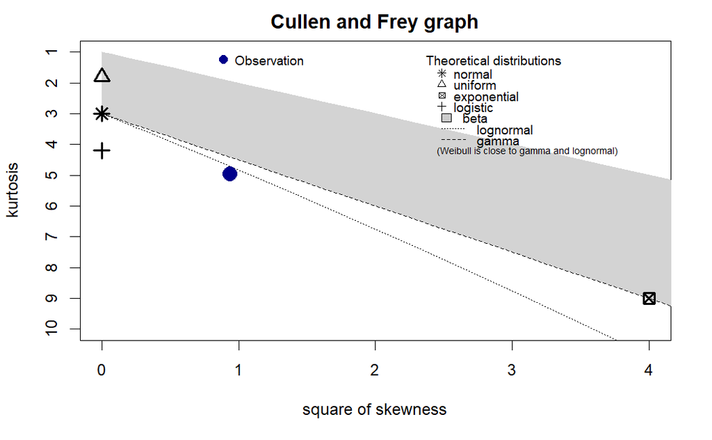

```r
fitdistrplus::descdist(test_data$resid)
```

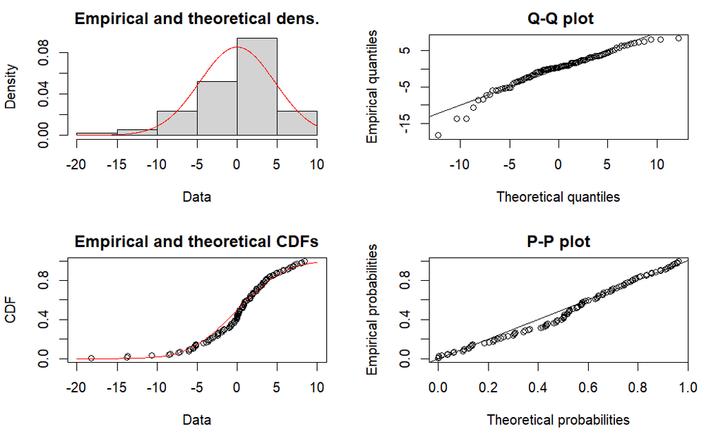

```r
normal_dist = fitdistrplus::fitdist(test_data$resid,"norm")
plot(normal_dist)
```

x~y scatterplot, residual stderror, kexi verteilung